# Australian Grand Prix Fantasy League Report

Guday managers, we're back! We are so back. Welcome to the first race report of the 2025 Formula 1 Fantasy League season, and it comes to you from the wonderful Melbourne track. That's right, Australia is back as the season opener and I had forgotten just how much I missed it in that position. Nothing says F1 is back than a 4am race start on the semi-street circuit of Albert Park.

If you're new here, let me break it down for you. Every race week I write a little summary of the recent news, race results, and the fantasy league scores. I also give details on any upcoming prizes that are in play, and comment on the next race. It's as simple as that. Keep in mind, anything written here is either a fact or opinion, so try not to take things too personally and let's have some fun.

## The News

### Rookies and Legends

After a completely stagnant driver market in the 2024 season, we have got the biggest shakeup in recent F1 history. Only two teams kept their driver lineup going into the 2025 season, World Constructors' Champions McLaren and Aston Martin. 6 rookies joined the grid this year, and yes I use that word fairly loosely since there are a couple of those rookies who have completed their fair share of Grand Prix. Starting in no particular order, we are joined this year by Oliver Bearman, Isack Hadjar, Jack Doohan, Gabriel Bortoleto, Liam Lawson, and Andrea Kimi Antonelli who are all desperate to prove themselves in this ultra competitive sport. Of those 6, two have completed more than 1 F1 Grand Prix (Bearman and Lawson), one has completed a single Grand Prix (Doohan), and the others are fresh-faced rookies in a competitive session. Bortoleto is, of course, the reigning F2 champion who competed in a fierce competition against Prema drivers Antonelli and Bearman, and Hadjar. Doohan spent last year as the Alpine reserve driver, Lawson stood in for an injured Ricciardo in 2023 and replaced Ricciardo at the end of the 2024 season. They will all be desperate to hit the ground running in Australia that's for sure.

At the other end of the spectrum, we have Fernando Alonso and Lewis Hamilton; two legends of the sport who are now the two most experienced F1 drivers in history. Fernando goes into his 23rd season of F1, starting for Minardi in 2001, having completed 404 entries prior to the Australian Grand Prix. Lewis goes into his 19th consecutive F1 season with a total of 356 entries prior to the Australian Grand Prix. While the former stays with their Aston Martin team this year, it is the latter who is getting all the attention after their shock move to Ferrari, announced early last year. The media are circling the 7-time world champion as he sets out on a mission to secure an eighth title with the Scuderia, a feat that would see him break the long-standing record he shares with Michael Schumacher. Joining them in terms of experience, though not quite in terms of race entries, is Max Verstappen, who goes into his 11th season of F1 in hunt of that fifth World Drivers' Championship, which would see him equal Michael Schumacher with 5 consecutive titles. Max hasn't had it all his way in the last year, and the competition is fierce. If he can do it, Max will have dominated this entire regulation period and could go into the next set of regulations on a high note.

### McLaren On Form

McLaren went into the winter break as World Constructors' Champions, the first time they have achieved this since 1998, on a high. Their pace at the end of last season was only equalled by Max in the Red Bull by the final handful of races, and everyone expects them to be the team to beat after winter testing. It seems for the first time in a long time, McLaren are going into a new season with a good car under their belt, having started last year with a bit of a midfield runner and building on the development over the course of the season. Norris is keen to downplay the strength of the McLaren car, focusing instead on his and Oscar's performances in winter testing. The Woking team signed a multi-year extension with Australian Oscar Piastri in the build up to the weekend, which was probably because of the hype around the young McLaren driver at his home Grand Prix, but did feel rather connected to the recent series of Driver To Survive. If you haven't seen it, there's a good interview with Christian Horner about which McLaren driver he would sign if he could, and he answers in favour of the Australian. It's a gamble for McLaren, as we have seen in the past that equally skilled and equally competitive drivers in a top team doesn't always go in the way of the "Dream Team" as one might hope. Are they going to have the advantage required to let their drivers fight, or are they going to finally have to make some tough decisions about who gets priority?

### Domenicali To Stay

Stefano Domenicali rose to the F1 management position during the Covid-19 pandemic, aiming to take the sport in a new direction and guide us into the future. The former Ferrari man has take the sport's calendar to a record breaking 24-long calendar, adding races in the Middle East and North America, with the addition of Las Vegas marking the first time F1 has been the promoter of the event. Domenicali was instrumental in introducing the cost cap, which has saved some of the teams who were fighting for scraps at the bottom of the table and put the sport in a much better and far more competitive state than it used to be in the early 2010s era. After such success, it makes sense that he has just signed a five-year extension to his contract to continue to guide this wonderful sport until the end of the 2029 season.

## Grand Prix Report

Alright, I have waffled enough for one report, you're not here to read the news or my attempts at some Australian slang, you're here because you want to know what happened in the race and see if I write any slander at any one particular team or driver. You're probably also here because you want to see if I've turned into a Lewis Hamilton fan overnight. So let's get into it.

### Qualifying Report

A crash in free practice left rookie Oliver Bearman with gearbox issues early in Q3, the Brit didn't return to the track after pitting early in the sessions for repairs. Not the start he would have wanted that's for sure. After months of teases about the pace in that McLaren, it was first blood to Lando Norris who went fastest in the first part of qualifying ahead of Verstappen. But that wasn't the biggest surprise down the grid, Williams were. Sainz and Albon looked fast all throughout the first part of qualifying, finally showing how good that Williams car has become. They weren't the only ones either, both Kick Sauber cars also looked good, with rookie Bortoleto knocking out Antonelli in his first qualifying session. His teammate Hulkenberg was also knocked out, only managing seventeenth position, behind Antonelli, but ahead of Lawson, and the other Haas of Esteban Ocon. A shocking first session for Kimi and Liam, who showed that it's not just about the car.

Q2 started and it was again in McLaren's favour, it seemed to be turning out to be a three horse race for pole position between the Papaya boys and the Dutchman. Alonso took a nice trip across the gravel and causing a little damage to his floor in the process. Ferrari were not showing particularly amazing pace, and in the last few minutes the camera panned to a spinning Lewis Hamilton. It was a fortunate mistake though, as it meant drivers behind couldn't improve in the final sector. The biggest loser in that situation was rookie Isack Hadjar who seemed to be on the cusp of a Q3 appearance in his first session. He was joined in elimination by Fernando Alonso, Lance Stroll, Jack Doohan, and Gabriel Bortoleto.

Finally the gloves can come off. No more hiding, this matters now as the green light for the first Q3 of the season flies. Leclerc took the first honours as the McLaren of Norris had a lap time deleted, but he was quickly displaced by the reigning world champion, showing that there is definitely pace in that Red Bull. Norris and Piastri lined up first and second, as Charles Leclerc bailed on his final lap and pitted. The Dutchman couldn't match the McLarens, he lines up third ahead of George Russell in fourth. Yuki Tsunoda impressed to put his Racing Bull in fifth place, prompting Zak Brown to suggest that Red Bull maybe signed the wrong driver. Alex Albon shone with his Q3 appearance, the Thai driver able to put his Williams in sixth ahead of both Ferraris, Gasly in ninth and Sainz rounding out the top ten in his first appearance in blue.

### Race Report

How often do we hear in a race week that it is going to rain on race day, then race day rocks up and there's no sign of rain? Well Australia delivers again. It's not enough that this track has four DRS zones, high speed sections that could rival Monza, tight sections that could compete with some of the tighter street circuits, and often baking heat that can cook the drivers..., no now we need rain. A wet race often spawns chaos, and that's exactly what we got. Before the race even got going, Isack Hadjar span into the barrier at turn 2, breaking his rear wing and ending his race on the formation lap. The rookie walked back through the pits with his helmet firmly on, in a moment that felt like we shouldn't be watching.

The race eventually got going and all the drivers got away safely, that was until we reached the second sector, just after the stadium section, where Jack Doohan collided with the barrier ruining his brand new Alpine machine. The safety car was deployed, under which Carlos Sainz span at the final corner and collided with the barrier, ending his first foray with Williams early. The Spaniard apparently suffered with a weird upshift under safety car mode, and returned to the Williams garage to act as a strategist. In all that chaos, it was almost possible to forget that Verstappen had got the jump on Piastri at the start, and as they got going he was all over the back of Lando Norris. That was until the inters began to overheat, well they did for 15 of the remaining cars, and the Dutchman ran wide and was swallowed up by a charging Piastri.

The McLarens charged off, and as the weather was looking like it might dry or it might chuck it down at the halfway point, Piastri was told to hold back and not attack Lando as they worked their way through some lapped traffic. That really broke Piastri's rhythm and the Aussie dropped back, giving his teammate some breathing room. After another safety car, the result of a crash from Fernando Alonso, both McLarens pitted for dry tyres. That worked and they pulled a good gap on Verstappen behind after the safety car, but as the weather changed again, they both ran wide going into the final sector. Piastri went a little wider than his teammate and beached his McLaren in the grass. We watched on as he backed out slowly, but it was too little too late. The Aussie was down at the back of the grid, and after another safety car, for Liam Lawson this time, he was able to salvage some points in the dying stages. Lando took a close victory over the reigning world champion in second, with Russell rounding out the podium in a solid but underwhelming performance.

Let's talk about the Ferrari pain then. That's what you're all waiting for. It was a bit of a disaster for the scuderia. Leclerc and Hamilton both asked to be left alone very early in the race, but managed to fight their way up to the lead under one of the safety car periods, but they had stayed out on dry tyres. As the clouds began to clear, and it seemed like dry tyres might have been the brave choice, they both pitted and dropped down the order. Leclerc managed to fight his way through to eighth while Hamilton dropped a place to Piastri in the dying moments. On top of that disappointment, there was some more team radio memes. Leclerc's car was slightly filled with water, which poised a great response from his engineer "It must be the water", and Hamilton was repeatedly told to use K1 and DRS, but again asked to be left alone. Not the start to the season they wanted.

Standout drivers that sort of flew under the radar this week, were Kimi Antonelli who fought his way back up to finish in fourth place behind his teammate, in the wet, while other rookies really struggled. Alex Albon who took that Williams to their best result since the Belgian Grand Prix of 2021 in fifth place. Lance Stroll, who had a pretty uneventful race to finish in sixth. Nico Hulkenberg, who took what we all thought was going to be the worst car on the grid and beat both Ferraris in seventh place. Finally, Yuki Tsunoda, who spent most of the race battling with Albon in the top five, but was dealt an absolutely shocking strategy by the team and could only recover to twelfth, that one will fly under the radar, but those of us who know, know that he had an absolutely great race.

## Fantasy League Scores

Scores for drivers/constructors in the current year's fantasy league, along with manager/team points, values, and statistics. Note: driver and constructor values are taken as the cost to enter the current race and are updated the week before the race.

## Lineup Scores

Right, let's get into it then, who came out on top in the fantasy league, and who's wallowing in misery at the bottom of the league after only the first week? Well to start with, we have to take a look at the Driver/Team points for the 2024 grid.

Well, it's first blow to race winner Lando Norris this week, who tops the tables with 59 points. The McLaren man barely put a foot wrong all weekend and tops the table with 59 points. He's ahead of rookie sensation Kimi Antonelli who climbed through the grid to secure himself 32 points in second ahead of reigning champion Max Verstappen with 29 points. George Russell brings it home in a safe fourth with 25 points, and Nico Hulkenberg rounds out the top five with 20 points. Our trio of early DNFs are at the bottom with -20 points, these are Fernando Alonso, Isack Hadjar, and Jack Doohan. They're closely followed by Carlos Sainz in second with -19, saved only by his qualifying performance. Gabriel Bortoleto, who had a weird off in the final sector, is in third with -18 points, with Liam Lawson in fourth with -17 points. Yuki Tsunoda, despite having a mega race, rounds out the bottom five with 0 points in Australia.

McLaren take the top step this week with 71 points ahead of Mercedes in second with 67. These two are leaps ahead of the chasing pack, with Ferrari occupying third place with 36 points. Alpine are at the bottom of the table with -14 points, ahead of Racing Bulls with -10. Aston Martin round out the bottom three with a singular point.

As it's the first race of the season, all the points are the total points, so I won't discuss them here now, but I will for the next race.

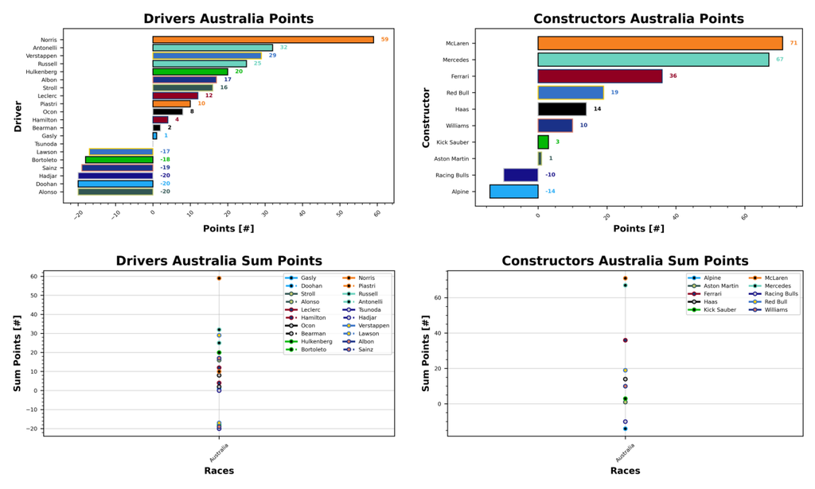

No longer is Max Verstappen the most expensive driver on the grid. That honour is taken by Lando Norris, with a value of $29.6, ahead of the Dutchman with $28.4. Charles Leclerc is more expensive than his more-experienced teammate with a value of $25.9, Lewis coming in at a modest $24.2. Oscar Piastri is the fifth most expensive driver with a value of $23.0. Reigning F2 champion, Bortoleto, is the cheapest driver on the grid with a value of $6.0, ahead of Isack Hadjar with a value of $6.2. Rather insultingly, Nico Hulkenberg is next with a value of $6.4, followed by Bearman with a value of $6.7. Rounding out the cheap five is Jack Doohan at $7.2.

McLaren are your most expensive team, with a value of $30.0 exactly. Then it's Ferrari at $27.4 and Mercedes at $26.7, expect those to change for China. Kick Sauber are your cheapest team at $6.2, followed by Haas at $7.0 and Racing Bulls at $8.0.

All values are in $M.

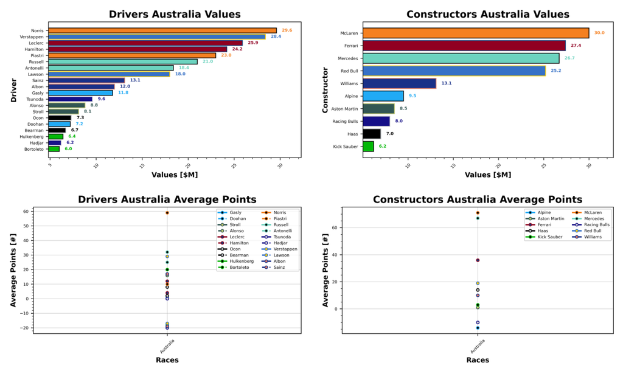

Your driver of the week was Nico Hulkenberg, with a points per value (bang for your buck) of 3.12 ppm. Race winner Norris is in second with 1.99 ppm, followed closely by Lance Stroll at 1.98 ppm. Kimi Antonelli put in a good points haul to come in at 1.74 ppm, ahead of Alex Albon in fifth with 1.42 ppm. Your worst driver of the week was Isack Hadjar at -3.23 ppm, ahead of Gabriel Bortoleto at -3.0 ppm. Jack Doohan is next with -2.78 ppm, followed by Fernando Alonso with -2.27 ppm. Carlos Sainz goes from the driver of the week in Abu Dhabi 2024 to rounding out the bottom five with -1.45 ppm.

Your team of the week, demonstrating their ability to win 8 consecutive titles, is Mercedes with a points per value of 2.51 ppm, ahead of reigning champions McLaren with 2.37 ppm. Haas round out the top three with a 2.0 ppm haul. Alpine are your worst team of the week, coming in at -1.47 ppm. Racing Bulls are next with -1.25 ppm. Aston Martin round out the bottom three with 0.12 ppm.

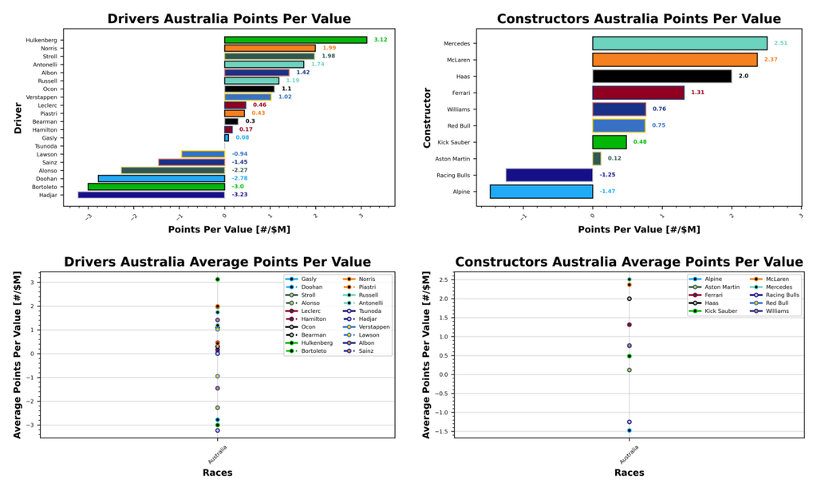

### Manager Scores

Now it's time to take a look at who has come out on top in the first race weekend of the season. Ordinarily, I would do a weekly score and a total score, and present results for averages and such. But since this is the first race of the season, these are all meaningless. Instead let's focus on the leaderboard for the week.

Sebastian is the manager to take the first victory this year, with their team Bridgestone Toro Rosso F1, coming in with 201 points ahead of Phil and BMW FTW who take a close second with 198. Chloe is an even closer third with Miss Fritter Is Back with 197 points. Then we have Val in fourth with It's 'odinge' and 186 points. Rounding out the top five this week is rookie manager Alfie with their team I Call Patrick Subaru bringing home 161 points.

Down at the slow end, it's Valeria and What Arrrgh Ya Doohan who take the honours in the Golf League at the season opener with -39 points. They're closely followed by James and Bwoah Schweppes Puma Golf with -37 points, looking to defend that title from last year. Then we have Pete with Seagiant F1 Online with a -35 points haul, ahead of Valeria with Perez For World Champion bringing home -24 points. Rounding out the bottom five is Stuart and Taylormade To Lose with -19 points.

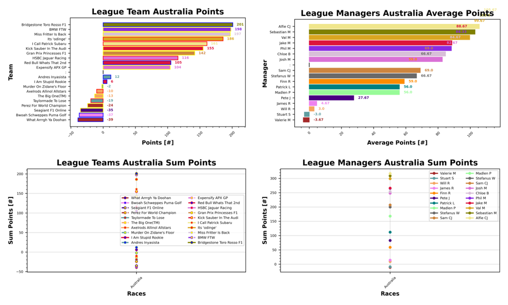

Nobody used any perks in the first race of the season, which I think is quite impressive to be honest, normally we have one or two use a perk early on. That just goes to show the caliber of the managers we have this year, nobody is wanting to take that risk too early.

Carlos Sainz was your top pick this week, with 26 selections throughout the field, sadly for Carlos, this didn't work out the way many of you were hoping. He's closely followed by Isack Hadjar and Fernando Alonso in second with 22 selections. Then we have Nico Hulkenberg with 19 selections, followed by the Haas pairing of Ocon and Bearman, each with 18 selections. Rounding out the top selections is Gabriel Bortoleto with 15. Quite staggering that none of the top drivers were in that list. Kimi Antonelli, Liam Lawson, and George Russell were your least selected drivers this week with 2 selections each. They're followed by reigning champion Max Verstappen with 4 selections. Then we have Alex Albon with only 6, so many of you favouring the other Williams man. Oscar Piastri is the fourth least selected driver with 8, and Charles Leclerc rounds out the bottom five with 9 selections.

Ferrari were your most selected team of the week, with 17 selections throughout the field. McLaren and Kick Sauber tie for second with 14 selections, and Williams and Haas are third with 10 a piece. Mercedes were your least selected team with only 4 of you thinking they were the right fit. Red Bull were next with only 5, followed by Alpine with 6.

IT seems you couldn't decide who to DRS boost either this week with Lando Norris and Lewis Hamilton the favorites, with 9 of you selected them for that double score. Charles Leclerc is in second with 8 selections, and Oscar Piastri in third with only 6.

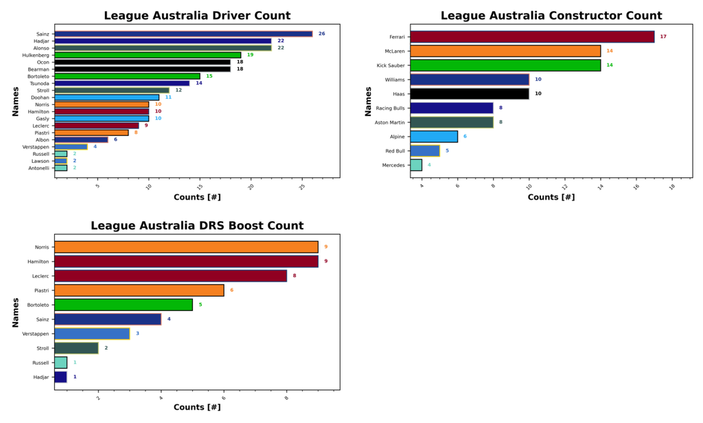

## Prizes

Australia was part of the continental prize, round 1 of that competition, which means currently it is Sebastian who is leading the way in that regard. China next is a sprint race, which means that too will be the first part of the sprint king prize. All to play for, keep it up.

## F1 Predict

F1 play has become F1 predict this year, the info for joining the league can be found on the website and Facebook page. Taking the top spot this week was Josh with 64 points, ahead of Roger Predictman (no idea which one of you this is), with 60 points. Phil came in in third with 55 points, ahead of Matty with 50. Stuart is at the back with only 45 points.

## Next Up

Next up is the Chinese Grand Prix, another staple of the F1 calendar and one of the old school tracks. Who will come out on top this week at the sprint race? Will McLaren be able to hold on to their advantage? Who knows.